# Exploring the Data of the English premiere League 2017-2018 Season statistics as obtained from football-data.co.uk

## To do this we are going to import some python libraries to facilitate this process

### That is:

- pandas
- matplotlib

```python
import pandas as pd
import matplotlib.pyplot as plt
%matplotlib inline
```

- Read the dataset for the 2017-2018 season located in ./data/E0_1718.csv using pandas.read_csv

```python
df1718=pd.read_csv("./data/E0_1718.csv")
```

- Let's check the shape of this dataset using df1718.shape

```python
df1718.shape
```

```
(380, 65)
```

We see that the dataset has 380 rows or entries and 65 columns or features

```python
df1718.head(5)
```

|  | Div | Date | HomeTeam | AwayTeam | FTHG | FTAG | FTR | HTHG | HTAG | HTR | ... | BbAv<2.5 | BbAH | BbAHh | BbMxAHH | BbAvAHH | BbMxAHA | BbAvAHA | PSCH | PSCD | PSCA |
| --- | --- | --- | --- | --- | --- | --- | --- | --- | --- | --- | --- | --- | --- | --- | --- | --- | --- | --- | --- | --- | --- |
| 0 | E0 | 11/08/17 | Arsenal | Leicester | 4 | 3 | H | 2 | 2 | D | ... | 2.32 | 21 | -1.00 | 1.91 | 1.85 | 2.10 | 2.02 | 1.49 | 4.73 | 7.25 |
| 1 | E0 | 12/08/17 | Brighton | Man City | 0 | 2 | A | 0 | 0 | D | ... | 2.27 | 20 | 1.50 | 1.95 | 1.91 | 2.01 | 1.96 | 11.75 | 6.15 | 1.29 |
| 2 | E0 | 12/08/17 | Chelsea | Burnley | 2 | 3 | A | 0 | 3 | A | ... | 2.23 | 20 | -1.75 | 2.03 | 1.97 | 1.95 | 1.90 | 1.33 | 5.40 | 12.25 |
| 3 | E0 | 12/08/17 | Crystal Palace | Huddersfield | 0 | 3 | A | 0 | 2 | A | ... | 1.72 | 18 | -0.75 | 2.10 | 2.05 | 1.86 | 1.83 | 1.79 | 3.56 | 5.51 |
| 4 | E0 | 12/08/17 | Everton | Stoke | 1 | 0 | H | 1 | 0 | H | ... | 1.76 | 19 | -0.75 | 1.94 | 1.90 | 2.01 | 1.98 | 1.82 | 3.49 | 5.42 |

5 rows × 65 columns

#### How many goals are scored by the Home Team and Away Team on average?

Using the columns FTHG, and FTAG we calculate the average With dataframe indexing we apply the mean function

```python
avg_fthg=df1718['FTHG'].mean()
avg_ftag=df1718['FTAG'].mean()
print("AVERAGE FULL TIME HOME GOALS: ",avg_fthg," AVERAGE FULL TIME HOME GOALS: ",avg_ftag)
```

```
AVERAGE FULL TIME HOME GOALS:  1.5315789473684212  AVERAGE FULL TIME HOME GOALS:  1.1473684210526316
```

- Clearly we see the home team scores more goals frequently than the away team.
- For every goal scored by the away team, how many goals are scored by the home team on average?

```python
ratio=avg_fthg/avg_ftag
print(ratio," : ",'1')
```

```
1.334862385321101  :  1
```

- Seems like the home team scores 33% more goals on average than the away team
- How many draws occurred on average in this season?

```python
ndraws=[i for i in range(380) if df1718['FTR'][i]=='D']
nhwins=[i for i in range(380) if df1718['FTR'][i]=='H']
nawins=[i for i in range(380) if df1718['FTR'][i]=='A']
print(len(ndraws)+len(nhwins)+len(nawins)==380) # Prove accuracy of the operation
print("Number of Draws: ",len(ndraws))
print("Number of Home Wins: ",len(nhwins))
print("Number of Away Wins: ",len(nawins))
```

```
True
Number of Draws:  99
Number of Home Wins:  173
Number of Away Wins:  108
```

- By the above statistics let's calculate the percentages thereof.

```python
phwins,pawins,pdraws=len(nhwins)/380,len(nawins)/380,len(ndraws)/380
print("Home wins: %f "%(phwins*100))
print("Draws: %f "%(pdraws*100))
print("Away wins: %f "%(pawins*100))
```

```
Home wins: 45.526316
Draws: 26.052632
Away wins: 28.421053
```

- So we see the Home Team won 46% of the games in this season, The away team 28% of them and 26% of the games ended in a draw

#### Let's Visualize this in a pie chart

```
Text(0.5,1,'A pie chart depicting the Full time results averages of the EPL 2017-2018 Season.')
```

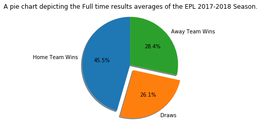

```python
labels=['Home Team Wins','Draws','Away Team Wins']
sizes=[phwins*100,pdraws*100,pawins*100]
explode=(0,0.13,0)

fig1, ax1 = plt.subplots()
ax1.pie(sizes, explode=explode, labels=labels, autopct='%1.1f%%',
        shadow=True, startangle=90)
ax1.axis('equal')  # Equal aspect ratio ensures that pie is drawn as a circle.
plt.title("A pie chart depicting the Full time results averages of the EPL 2017-2018 Season.")
```

- What about the half time results?

```
True
Number of Draws:  162
Number of Home Wins:  124
Number of Away Wins:  94
Home wins: 32.631579
Draws: 42.631579
Away wins: 24.736842
```

```
Text(0.5,1,'A pie chart depicting the Half time results averages of the EPL 2017-2018 Season.')
```

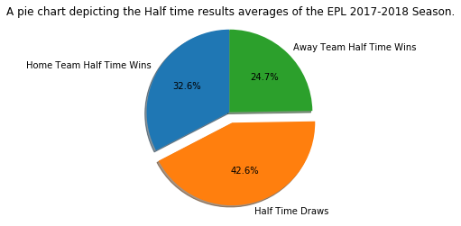

```python
# Calculating the number of events at Half time
nhtdraws=[i for i in range(380) if df1718['HTR'][i]=='D']
nhthwins=[i for i in range(380) if df1718['HTR'][i]=='H']
nhtawins=[i for i in range(380) if df1718['HTR'][i]=='A']
print(len(nhtdraws)+len(nhthwins)+len(nhtawins)==380) # Prove accuracy of the operation
print("Number of Draws: ",len(nhtdraws))
print("Number of Home Wins: ",len(nhthwins))
print("Number of Away Wins: ",len(nhtawins))

# Calculating Percentages
phthwins,phtawins,phtdraws=len(nhthwins)/380,len(nhtawins)/380,len(nhtdraws)/380
print("Home wins: %f "%(phthwins*100))
print("Draws: %f "%(phtdraws*100))
print("Away wins: %f "%(phtawins*100))

# Plotting the stats
labels=['Home Team Half Time Wins','Half Time Draws','Away Team Half Time Wins']
sizes=[phthwins*100,phtdraws*100,phtawins*100]
explode=(0,0.13,0)

fig1, ax1 = plt.subplots()
ax1.pie(sizes, explode=explode, labels=labels, autopct='%1.1f%%',
        shadow=True, startangle=90)
ax1.axis('equal')  # Equal aspect ratio ensures that pie is drawn as a circle.
plt.title("A pie chart depicting the Half time results averages of the EPL 2017-2018 Season.")
```

#### Interesting it seems the number of draws at Half Time are more than the number of Home Team wins.

##### To see this more clearly let us plot the two charts side by side...

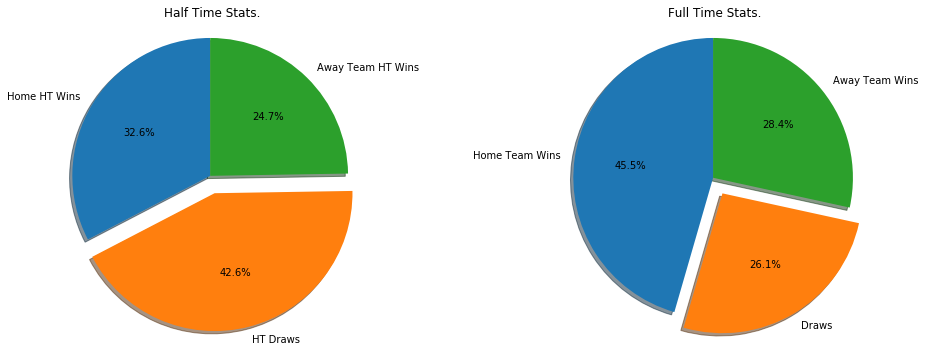

```python
fig2=plt.figure(figsize=(15,6))


axht=fig2.add_subplot(121)
labels=['Home HT Wins','HT Draws','Away Team HT Wins']
sizes=[phthwins*100,phtdraws*100,phtawins*100]
explode=(0,0.13,0)
axht.pie(sizes, explode=explode, labels=labels, autopct='%1.1f%%',
        shadow=True, startangle=90)
axht.axis('equal')  # Equal aspect ratio ensures that pie is drawn as a circle.
axht.set_title('Half Time Stats.')

axft=fig2.add_subplot(122)
labels=['Home Team Wins','Draws','Away Team Wins']
sizes=[phwins*100,pdraws*100,pawins*100]
explode=(0,0.13,0)
axft.pie(sizes, explode=explode, labels=labels, autopct='%1.1f%%',
        shadow=True, startangle=90)
axft.axis('equal')  # Equal aspect ratio ensures that pie is drawn as a circle.
axft.set_title('Full Time Stats.')

#plt.title("Comparing Half Time vs Full Time Results")
plt.subplots_adjust(wspace=0.5)
```

### Comparing Shots on Target with the number of goals scored in a game.

- Let us now compare the number of goals scored in the season with the number of shots on target.
- Is there a relationship between the number of shots on target with the number of goals scored in a game?

```python
goals_per_match=df1718['FTHG']+df1718['FTAG']
shots_target_per_match=df1718['HST']+df1718['AST']
len(goals_per_match)==len(shots_target_per_match)
```

```
True
```

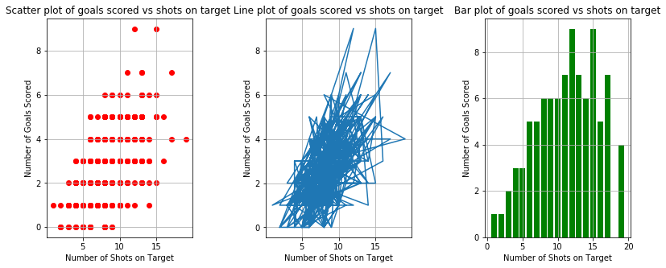

```python
#### Let's Visualize these stats using a scatter plot and a line plot.
fig3=plt.figure(figsize=(13,5))
ax1=fig3.add_subplot(131)
ax1.scatter(shots_target_per_match,goals_per_match,color='r')
ax1.set_title("Scatter plot of goals scored vs shots on target ")
ax1.set_xlabel("Number of Shots on Target")
ax1.set_ylabel("Number of Goals Scored")
ax1.grid(True)

ax2=fig3.add_subplot(132)
ax2.plot(shots_target_per_match,goals_per_match)
ax2.set_title("Line plot of goals scored vs shots on target")
ax2.set_xlabel("Number of Shots on Target")
ax2.set_ylabel("Number of Goals Scored")
ax2.grid(True)

ax3=fig3.add_subplot(133)
ax3.bar(shots_target_per_match,goals_per_match,color='g')
ax3.set_title("Bar plot of goals scored vs shots on target")
ax3.set_xlabel("Number of Shots on Target")
ax3.set_ylabel("Number of Goals Scored")
ax3.grid(True)
plt.subplots_adjust(wspace=0.5)
```

### Next steps: Could we possibly predict the Full Time Result Given Past Data?

#### Which attributes would be useful in prediction if we could?

#### How much data is sufficient to train a Machine Learning or Statistical Model?